# Decomposition of clonal HSC transcriptomes (LARRY/DARLIN)

```r
require(Seurat)
require(hsc19)
require(plyr)
require(ggplot2)
require(ggnewscale)
require(ggrepel)
set.seed(1337)
```

## Summary

This vignette decomposes clonal HSC transcriptomes into 19 GRPs and identifies associations with clone function. It investigates both post-transplant hematopoiesis (using [LARRY barcodes](https://doi.org/10.1038/s41586-020-2503-6)) and native hematopoiesis (using DARLIN barcodes)

## Process LARRY

### Data preparation

We download a LARRY scRNA-seq dataset (from [Scherer et al., 2025](https://www.nature.com/articles/s41586-025-09041-8)), subset to cells annotated as HSC/MPP1, and compute pseudobulks per clone. We also compute clonal properties, such as the output (non-HSC per HSC) and whether the clone has any output.

```r
if (!file.exists("data_LARRY/seurat_LK_LSK.RDS")) download.file(
  "https://ndownloader.figshare.com/files/42587815",
  destfile = "data_LARRY/seurat_LK_LSK.RDS",
  mode = "wb"
)

larry <- readRDS("data_LARRY/seurat_LK_LSK.RDS")
larry$LARRY <- gsub("_","-", larry$LARRY)
larry_HSC <- subset(larry, CellType %in% c("HSC/MPP1"))
larry_HSC_pseudobulk <- AggregateExpression(larry_HSC, group.by = "LARRY", return.seurat = T, verbose = F)
larry_HSC_pseudobulk <- FindVariableFeatures(larry_HSC_pseudobulk, verbose = F)
larry_HSC_pseudobulk <- AddModuleScore(larry_HSC_pseudobulk, features = alejo_lists, name = "alejo", verbose = F) #Add expression scores for gene signatures defined by others

clone_info <- ddply(larry@meta.data, "LARRY",summarise,
                    n = length(LARRY),
                    n_hsc = sum(CellType == "HSC/MPP1"),
                    n_nonhsc = sum(CellType != "HSC/MPP1"))
clone_info <- within(clone_info,{
  f_clonesize <- n/sum(n)
  A_output <- (n_nonhsc / sum(n_nonhsc)) / (0.0001 + (n_hsc / sum(n_hsc)))
  use <- n_hsc > 0
})

clone_info <- subset(clone_info, !is.na(LARRY))
rownames(clone_info) <- clone_info$LARRY
clone_info <- merge(clone_info, larry_HSC_pseudobulk@meta.data[, grepl("LARRY|alejo", colnames(larry_HSC_pseudobulk@meta.data))])
colnames(clone_info)[grepl("alejo", colnames(clone_info))] <- names(alejo_lists)

clone_info$output_log <- log10(clone_info$A_output+ 0.01)
clone_info$size_log <- log10(clone_info$f_clonesize)
clone_info$output_binary <- clone_info$A_output > 0

rownames(clone_info) <- clone_info$LARRY
```

### Decompose data into GRPs

```r
result_larry <- decompose(s = larry_HSC_pseudobulk)
```

```
#> Run on 131 samples. On the overlapping gene set of 820 genes, 19 programs explain 14.0 % of the gene expression variance in your data. For comparison, 19 principal components explain 44.1 %
```

### Associate GRPs with clone function

The `associate` function here computes both p-value associations, and runs machine learning to compare the predictve value of these predictors, other predictors, and the whole transcriptome (see also manuscript, methods section)

```r
grp2output_larry_output <- associate_numeric_outcome(result_larry, clone_info, "output_log", other.predictors = names(alejo_lists), run.ML = T, replicates = 10, cores = 10, genelists = alejo_lists)

grp2output_larry_binary <- associate_binary_outcome(result_larry, clone_info, "output_binary", other.predictors = names(alejo_lists), run.ML = T, replicates = 10, cores = 10, genelists = alejo_lists, ROCs = T) #captures if it
```

## Process DARLIN

**Data preparaiton is conceptually the same as in LARRY, but a bit more involved (click to expand).**

First, download the complete DARLIN Data and code.

```bash
wget -O DARLIN_public.zip https://zenodo.org/records/11929508/files/DARLIN_public.zip?download=1
unzip DARLIN_public.zip
```

Second, reproduce the code by the DARLIN authors to create an adata object that contains clone & cell type info. This code is based on a package, COSPAR, that was not trivial to install, I used:

```bash
conda create -n cospar-pip -c conda-forge python=3.10 pip
conda activate cospar-pip
pip install "scikit-learn>=1.2" scanpy cospar
```

And then I had to fix the code in `envs/cospar-pip/lib/python3.10/site-packages/cospar/tool/_clone.py` to replace some instances of `.A` by `toarray()`. Then I prepared an `adata` object in python that had both clone and transcriptome / cell type annotation info.

```python
import cospar as cs
import scanpy as sc
import pandas as pd
import scipy.sparse as ssp
import seaborn as sns
from matplotlib import pyplot as plt
import numpy as np
import os

## setting cospar
cs.logging.print_version()
cs.settings.verbosity=0

## notebook specific parameters
target_sample='20220815_LL837_10X_3A'
read_cutoff=3 # Read cutoff: each UMI must be covered by at least 3 reads
max_rep_N=1 # Mouse replicate number cutoff: this allele can appear in less than max_rep_N mouse samples in our allele bank
tissues=['Femur','Skull' , 'Spleen' ]

## setup folders
root_path='DARLIN_public/DATA' # the directory where data is located
sc.settings.figdir=figure_path
cs.settings.figure_path=figure_path
saved_adata_path='data_LARRY/tissue_adata_refined_20221106_joint.h5ad'

RNA_path=f'{root_path}/{target_sample}/RNA/result_RNA_10X/data/tissue_removeCycle_adata_preprocessed.h5ad'
adata=sc.read(RNA_path)
adata.obs['cell_type']=adata.obs['cell_type'].replace({'Meg': 'MkP'})

#### Load clone data and integrate with RNA data
#The UMI count here is for the same allele across all cells, not within the same cell
df_sc_data=pd.read_csv(f'{root_path}/{target_sample}/df_sc_data_{read_cutoff}.csv')

#this data has correct UMI count information
df_sc_data['RNA_id']=df_sc_data['sample'].apply(lambda x: '_'.join(x.split('-')))+'_'+df_sc_data['cell_bc']

# Identify reliable alleles and the corresponding RNA_id (UMI) should match that with transcriptome information
df_sc_data_HQ_with_RNA=df_sc_data[(~pd.isna(df_sc_data['joint_prob']))
                         & (df_sc_data['sample_count']<=max_rep_N)
                         & (df_sc_data['RNA_id'].isin(adata.obs_names))] # & (df_sc_data['joint_allele_num']<5)]

if not (df_sc_data['sample_count'].max()==3):
    raise ValueError('Should only use the Gr allele bank with 3 samples')

cs.pp.get_X_clone(adata,df_sc_data_HQ_with_RNA['RNA_id'],df_sc_data_HQ_with_RNA['joint_clone_id'])

cs.pp.initialize_adata_object(adata)

adata.write_h5ad(saved_adata_path)

# df_clone=cs.tl.clone_statistics(adata,joint_variable='state_info');
# df_clone.to_csv("data_LARRY/DARLIN_clone_info.csv")
```

Finally I loaded this in R and performed the subsetting and pseudobulk calculation

```r
require(anndata)
data <- read_h5ad("data_LARRY/tissue_adata_refined_20221106_subset.h5ad")
clone_id <- apply(data$obsm$X_clone, 1, function(x) if(any(x > 0)) which(x > 0)-1 else NA)
S <- CreateSeuratObject(counts = t(as.matrix(data$X)), meta.data = data$obs,min.features = 500, min.cells = 30)
names(clone_id) <- colnames(S)
S <- AddMetaData(S, clone_id, col.name = "clone_id")

S <- NormalizeData(S)
S <- FindVariableFeatures(S)
S<- ScaleData(S)
S<- RunPCA(S)
S<- FindNeighbors(S, dims=1:30)
S<- FindClusters(S)
S <- RunUMAP(S,dims = 1:20)

capitalize <- function(x) {
  sapply(x, function(y) {
    if (is.na(y) || y == "") return(y)
    paste0(toupper(substr(y, 1, 1)), tolower(substr(y, 2, nchar(y))))
  }, USE.NAMES = FALSE)
}

S <- CellCycleScoring(S, capitalize(cc.genes$s.genes),capitalize(cc.genes$g2m.genes))
#FeaturePlot(S, c("S.Score","G2M.Score"))
#there is a massive group of cells in cycle
#get rid of this
S <- subset(S, idents = c(1,11,5,4,6), invert=T)

S <- NormalizeData(S)
S <- FindVariableFeatures(S)
S<- ScaleData(S)
S<- RunPCA(S)
S<- FindNeighbors(S, dims=1:30)
S<- FindClusters(S)
S <- RunUMAP(S, dims = 1:30)

#properly dissect those
darlin_HSC <- subset(S, cell_type %in% c("HSC"))

darlin_HSC <- NormalizeData(darlin_HSC)
darlin_HSC <- FindVariableFeatures(darlin_HSC, nfeatures = 1000)
darlin_HSC<- ScaleData(darlin_HSC)
darlin_HSC<- RunPCA(darlin_HSC)
darlin_HSC<- FindNeighbors(darlin_HSC, dims=1:20)
darlin_HSC<- FindClusters(darlin_HSC)
darlin_HSC <- RunUMAP(darlin_HSC, dims = 1:20)
#FeaturePlot(darlin_HSC, c("Ly6a","Hlf")) #seems appropriate

darlin_HSC_pseudobulk <- AggregateExpression(darlin_HSC, group.by = "clone_id", return.seurat = T)
darlin_HSC_pseudobulk <- FindVariableFeatures(darlin_HSC_pseudobulk, verbose = F)
darlin_HSC_pseudobulk <- AddModuleScore(darlin_HSC_pseudobulk, features = alejo_lists, name = "alejo", verbose = F)
saveRDS(darlin_HSC_pseudobulk, "data_LARRY/DARLIN_pseudobulks.rds")
```

Finally I computed summaries of clone function

```r
darlin_clone_info <- ddply(S@meta.data, "clone_id",summarise,
                    clone_size = length(clone_id),
                    n_hsc = sum(cell_type == "HSC", na.rm=T),
                    n_nonhsc = sum(cell_type != "HSC", na.rm=T),
                    n_mkp = sum(cell_type != "MkP", na.rm=T),
                    n_nonmkp = sum(cell_type != "MkP" & cell_type != "HSC", na.rm=T),
                    n_lmpp = sum(cell_type != "LMPP", na.rm=T),
                    n_nonlmpp = sum(cell_type != "LMPP" & cell_type != "HSC", na.rm=T),
                    n_celltypes = length(unique(cell_type)))
darlin_clone_info$clone_id <- paste0("g", darlin_clone_info$clone_id)
darlin_clone_info <- within(darlin_clone_info,{
  f_clonesize <- clone_size/sum(clone_size)
  A_output <- (n_nonhsc / sum(n_nonhsc)) / (0.0001 + (n_hsc / sum(n_hsc)))
  Mk_output <- (n_nonmkp / sum(n_nonmkp)) / (0.0001 + (n_mkp / sum(n_mkp)))
  Ly_output <- (n_nonlmpp / sum(n_nonlmpp)) / (0.0001 + (n_lmpp / sum(n_lmpp)))
  use <- n_hsc > 0
})

darlin_clone_info <- merge(darlin_clone_info, darlin_HSC_pseudobulk@meta.data[, grepl("clone_id|alejo", colnames(darlin_HSC_pseudobulk@meta.data))])
colnames(darlin_clone_info)[grepl("alejo", colnames(darlin_clone_info))] <- names(alejo_lists)

darlin_clone_info$output_log <- log10(darlin_clone_info$A_output+ 0.01)
darlin_clone_info$output_binary <- darlin_clone_info$A_output>0
darlin_clone_info$mk_binary <- darlin_clone_info$Mk_output>0
darlin_clone_info$ly_binary <- darlin_clone_info$Ly_output>0
darlin_clone_info$f_clonesize_log <- log(darlin_clone_info$f_clonesize)
# darlin_info$clone_id <- paste0("g", darlin_info$clone_id)
# darlin_clone_info <- merge(darlin_clone_info, darlin_info, all.x = T)
rownames(darlin_clone_info) <- darlin_clone_info$clone_id
saveRDS(darlin_clone_info, file = "data_LARRY/DARLIN_clone_info.rds")
```

### Decompose data into GRPs

```r
darlin_HSC_pseudobulk <- readRDS("data_LARRY/DARLIN_pseudobulks.rds")
result_darlin <- decompose(s = darlin_HSC_pseudobulk)
```

```
#> Run on 281 samples. On the overlapping gene set of 815 genes, 19 programs explain 8.7 % of the gene expression variance in your data. For comparison, 19 principal components explain 25.0 %
```

### Associate GRPs with clone function

```r
darlin_clone_info <- readRDS("data_LARRY/DARLIN_clone_info.rds")
grp2output_darlin_output <- associate_numeric_outcome(result_darlin, darlin_clone_info, "output_log", other.predictors = names(alejo_lists), run.ML = T, replicates = 10, cores = 10, genelists = alejo_lists)

grp2output_darlin_binary <- associate_binary_outcome(result_darlin, darlin_clone_info, "output_binary", other.predictors = names(alejo_lists), run.ML = T, replicates = 10, cores = 10, genelists = alejo_lists, ROCs = T)
```

## Create figures

### Figure 3D: P values

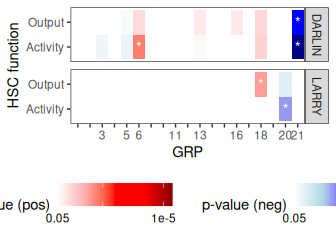

```r
D <- list(larry_output = grp2output_larry_output, larry_activity = grp2output_larry_binary,
          darlin_output = grp2output_darlin_output, darlin_activity = grp2output_darlin_binary)
pvalues <- lapply(D, "[[", 1)
pvalues <- lapply(names(pvalues), function(n) { x <- pvalues[[n]]; x$phenotype <- n; x} )

pvalues <- do.call(rbind, pvalues)
pvalues$experiment <- toupper(gsub("_.+", "", pvalues$phenotype))
pvalues$phenotype <- gsub("larry_|darlin_", "", pvalues$phenotype)
pvalues$show_value <- with(pvalues, ifelse(p_outcome < 0.1, -log10(p_outcome), log10(0.1)))
pvalues <- subset(pvalues, grepl("Factor_", factor_id))
factor_levels <- get_factor_columns(result_larry)
pvalues$factor_id <- factor(pvalues$factor_id, levels = factor_levels)
labels <- c( "output" = "Output", "activity" = "Activity")
ylabels <- gsub("Factor_", "", factor_annotation$factor_id); names(ylabels) <- factor_annotation$factor_id
any_sig <- sapply(names(ylabels), function(x) any(pvalues$p_outcome[pvalues$factor_id == x] < 0.05))
ylabels[!any_sig] <- ""
pvalues <- merge(pvalues, factor_annotation)

fig3d <- ggplot(aes(x = factor_id, y = phenotype), data = pvalues) +
  geom_blank() +
  geom_tile(aes(fill =show_value), data = subset(pvalues, p_outcome < 0.05 & sign_outcome * multiply_with == -1)) +
  scale_fill_gradientn(name = "p-value (neg)", colors = c("white","lightblue","blue", "blue", "darkblue"), breaks = c(-log10(0.05), -log10(0.1 / (19*4)), 5), labels = c("0.05", "", "1e-5"), limits = c(-log10(0.05), max(pvalues$show_value)), na.value = "white") +
  new_scale_fill() +
  geom_tile(aes(fill =show_value),data = subset(pvalues, p_outcome < 0.05 & sign_outcome * multiply_with == 1)) +
  geom_text(aes(label = ifelse(p.adjust(p_outcome,"fdr") < 0.1, "*", "")), color = "white",size=4) +
  scale_fill_gradientn(name = "p-value (pos)", colors = c("white","#FFAAAA","red", "red", "darkred"), breaks = c(-log10(0.05), -log10(0.1 / (19*4)), 5), labels = c("0.05", "", "1e-5"), limits = c(-log10(0.05), max(pvalues$show_value)), na.value = "white") +
  facet_grid(experiment~.) + scale_y_discrete(labels = labels, name = "HSC function") +  scale_x_discrete(name = "GRP", labels = ylabels) +
  theme_bw() + theme(panel.grid = element_blank(), legend.position = "bottom") + scale_size_area(guide= "none", max_size = 3) +
  scale_shape_manual(values = c("1" = 24, "-1" = 25), guide="none")

print(fig3d)
```

### Figure 3E: Box plots

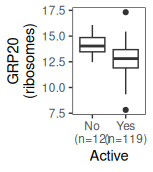

```r
forplot <- cbind(clone_info, t(result_larry@result))

fig3el <- qplot(x = output_binary, y = Factor_20 * factor_annotation$multiply_with[factor_annotation$factor_id == "Factor_20"], data = forplot, geom = "boxplot") + ylab("GRP20\n(ribosomes)") + scale_x_discrete("Active", labels = c("FALSE" = sprintf("No\n(n=%d)", sum(!forplot$output_binary)), "TRUE" = sprintf("Yes\n(n=%d)", sum(forplot$output_binary)))) +
  theme_bw() + theme(panel.grid = element_blank())
print(fig3el)
```

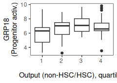

```r
forplot$A_output_discrete <- infotheo::discretize(forplot$A_output, nbins = 4)$X
fig3er <- qplot(x = as.factor(A_output_discrete), y = Factor_18 * factor_annotation$multiply_with[factor_annotation$factor_id == "Factor_18"], data = forplot, geom = "boxplot") + ylab("GRP18\n(Progenitor activ.)")+
    theme_bw() + theme(panel.grid = element_blank()) + scale_x_discrete("Output (non-HSC/HSC), quartiles", labels = paste(1:4,"\n"))
print(fig3er)
```

### Figure 3F: Predictive performance

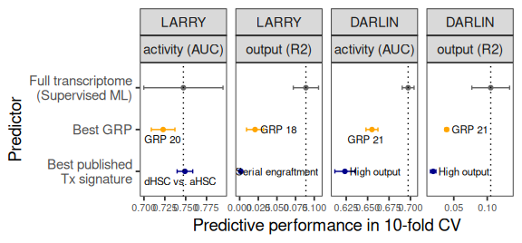

```r
predictive_performance <- data.frame(
  measure = do.call(c, lapply(D, function(x) names(x[[2]]))),
  auc.rqsr = do.call(c, lapply(D, "[[", 2)),
  auc.rqsr.sd = do.call(c, lapply(D, "[[", 3)))
predictive_performance$experiment <- ifelse(grepl("larry", rownames(predictive_performance)), "LARRY", "DARLIN")
predictive_performance$phenotype <- gsub(".+_(\\D+)\\d+","\\1",rownames(predictive_performance))
predictive_performance$zeroshot <- predictive_performance$measure %in% c("R2.best.factor", "R2.best.other", "AUC.best.factor", "AUC.best.other")
predictive_performance$grouping <- with(predictive_performance, ifelse(zeroshot, measure,ifelse(measure %in% c("AUC.lasso.factors","R2.lasso.factors"), "Supervised ML", "Supervised ML")))
simple <- ddply(predictive_performance, c("experiment","phenotype", "grouping"), summarise,
                best = max(auc.rqsr),
                best.sd = auc.rqsr.sd[which.max(auc.rqsr)],
                which.best =  measure[which.max(auc.rqsr)],
                percent = ifelse( grepl("best.factor|best.other", unique(grouping)),
                                 max(D[[sprintf("%s_%s", tolower(unique(experiment)), unique(phenotype))]][[gsub("AUC.|R2.", "", unique(grouping))]]), NA),
                best.list = ifelse( grepl("best.factor|best.other", unique(grouping)),
                                              names(which.max(D[[sprintf("%s_%s", tolower(unique(experiment)), unique(phenotype))]][[gsub("AUC.|R2.", "", unique(grouping))]])), NA)

                )
simple$best.list[is.na(simple$best.list)] <- simple$grouping[is.na(simple$best.list)]
otherlevels <- unique(simple$best.list); otherlevels <- otherlevels[!otherlevels %in% c("Supervised ML", factor_levels ) ]
simple$best.list <- factor(simple$best.list, levels = rev(c("Supervised ML", factor_levels, otherlevels )))
simple$which.best <- factor(simple$which.best, levels = c("R2.best.factor", "R2.best.other", "AUC.best.factor", "AUC.best.other", unique(simple$which.best[simple$grouping == "Supervised ML"])))

ylabels <- gsub("Factor_", "GRP ", unique(simple$best.list)); names(ylabels) <- unique(simple$best.list)
ylabels["High.output_Rodriguez_et_al"] <- "High output"
ylabels["Serial.engraftment_Rodriguez_et_al"] <- "Serial engraftment"
ylabels["Multilineage_Rodriguez_et_al"] <- "Multilineage"
ylabels["dHSC_aHSC_single.cell_Cabezas.Wallscheid_et_al"] <- "dHSC vs. aHSC"

for_combined_plot <- simple
for_combined_plot$simplegroup <- with(for_combined_plot, factor(gsub("AUC.|R2.", "", grouping), levels = rev(c("Supervised ML", "best.factor", "best.other"))))
faclabels <- c("output" = "output (R2)", "activity" = "activity (AUC)")
collabels <- c("Supervised ML" = "Full transcriptome\n(Supervised ML)", "best.other" = "Best published\nTx signature", "best.factor" = "Best GRP")

fig3f <- ggplot(aes(x = best, y = simplegroup, color = simplegroup), data=for_combined_plot) + geom_point() +
  geom_errorbarh(aes(xmin= best-best.sd, xmax = best+best.sd), height=0.1) +
  geom_text_repel(aes(label = ylabels[as.character(best.list)]), color = "black",size=3, data = subset(for_combined_plot, best.list != "Supervised ML")) +
  facet_wrap( ~  factor(experiment, levels = c("LARRY", "DARLIN")) + faclabels[phenotype], scales="free_x", nrow=1) +
  theme_bw(base_size=14) + theme(panel.grid = element_blank(), legend.position = "none",axis.text.x =element_text(size=8)) + scale_y_discrete(labels = collabels, name = "Predictor") +
  xlab("Predictive performance in 10-fold CV") + scale_x_continuous() +
  scale_color_manual( values = c("Supervised ML" = "#666666", "best.other" = "darkblue", "best.factor" = "orange"),
                      name = "Predictor", labels = collabels) +
 geom_vline(aes(xintercept = best), data=subset(for_combined_plot, grouping == "Supervised ML"), linetype = 3)

print(fig3f)
```